# Projekt z Uczenia Maszynowego

Maszyny Wektorów Nośnych (SVM): Spośród trzech testowanych jąder SVM (liniowe, radialne i wielomianowe), model z jądrem wielomianowym wyróżnił się najlepszą dokładnością, specyficznością i precyzją.

```r
str(oversampled_dane_treningowe)
```

```
## 'data.frame':    512 obs. of  9 variables:
##  $ zachmurzenie      : num  8 6.3 5.9 8 3.9 5.3 7.3 6.5 2.8 3.5 ...
##  $ wiatr             : num  2.8 5.3 3.8 2 2.3 2.4 3 2.8 6 1.1 ...
##  $ temperatura       : num  8.3 5.8 7 4.3 0.1 8.5 9.9 8.7 3.7 6.1 ...
##  $ rosa_01           : Factor w/ 2 levels "Brak","Rosa": 2 1 2 1 1 2 1 2 1 2 ...
##  $ szron_01          : Factor w/ 2 levels "Brak","Szron": 1 1 1 1 2 1 1 1 2 1 ...
##  $ mgla_01           : Factor w/ 2 levels "Brak","Mgla": 1 1 2 1 1 1 1 1 1 2 ...
##  $ pokrywa_sniezna_01: Factor w/ 2 levels "Brak","Pokrywa_sniezna": 1 1 1 1 1 1 1 1 1 1 ...
##  $ deszcz_01         : Factor w/ 2 levels "Brak","Deszcz": 1 2 1 1 1 2 2 1 1 1 ...
##  $ snieg_prognoza    : Factor w/ 2 levels "Brak","Snieg": 1 1 1 1 1 1 1 1 1 1 ...
```

```r
explain_logistic_train_over <- DALEX::explain(model = logistic_train_over,
                       data = oversampled_dane_treningowe[,-9],
                       y = oversampled_dane_treningowe$snieg_prognoza,
                       type = "classification",
                       label = "Logistic regression")
```

[output not shown]

```
##   -> residuals         :  numerical, min =  NA , mean =  NA , max =  NA
##   A new explainer has been created!
```

Model regresji logistycznej jest inicjalizowany w środowisku DALEX. Model ten jest skonfigurowany do przewidywania zmiennej snieg_prognoza na podstawie danych treningowych, które zostały wcześniej zbalansowane metodą oversampling. Obiekt explain stanie się podstawą do dalszej analizy interpretacyjnej modelu.

```r
obs <- oversampled_dane_treningowe[60,]
obs
```

```
##    zachmurzenie wiatr temperatura rosa_01 szron_01 mgla_01 pokrywa_sniezna_01
## 60          7.5   1.1         8.4    Brak     Brak    Mgla               Brak
##    deszcz_01 snieg_prognoza
## 60    Deszcz           Brak
```

Wybrano 60-tą obserwację z zestawu danych treningowych do analizy. Ta obserwacja zostanie użyta do szczegółowej analizy wpływu poszczególnych zmiennych na wynik modelu.

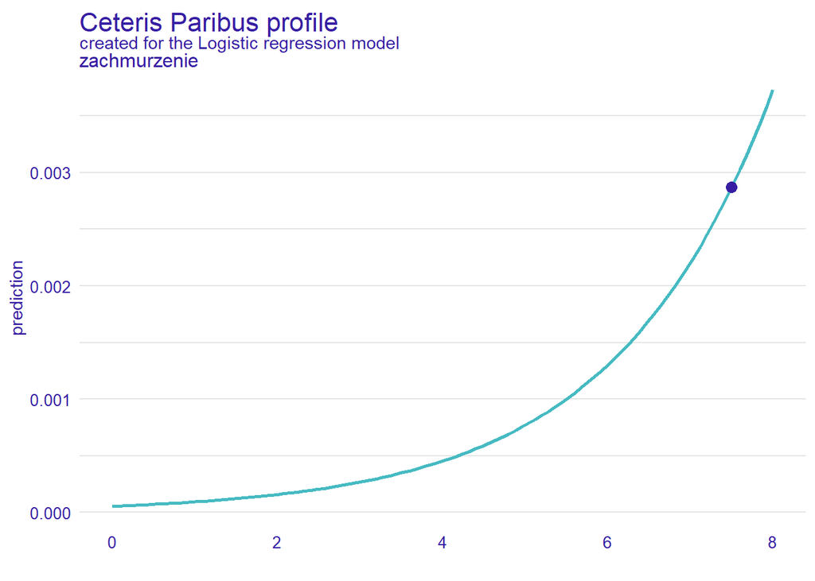

```r
pcp <- predict_profile(explainer = explain_logistic_train_over,
                       new_observation = obs)

plot(pcp, variables = c("zachmurzenie"))
```

Profil Ceteris Paribus pokazuje, jak zmienia się prognoza modelu uczenia maszynowego, kiedy wartość jednej zmiennej (w tym przypadku “zachmurzenie”) jest zmieniana, a wszystkie inne zmienne są utrzymywane na stałym poziomie.

Krzywa na wykresie rośnie, co sugeruje, że wraz ze wzrostem poziomu zachmurzenia, model przewiduje wyższe prawdopodobieństwo wystąpienia zdarzenia docelowego. Gwałtowny wzrost krzywej na prawym końcu wykresu wskazuje na to, że model jest szczególnie wrażliwy na wyższe wartości zmiennej “zachmurzenie”.

Niebieski punkt na wykresie prawdopodobnie reprezentuje prognozę dla faktycznej wartości zmiennej “zachmurzenie” w analizowanej obserwacji (60-tej z zestawu danych)

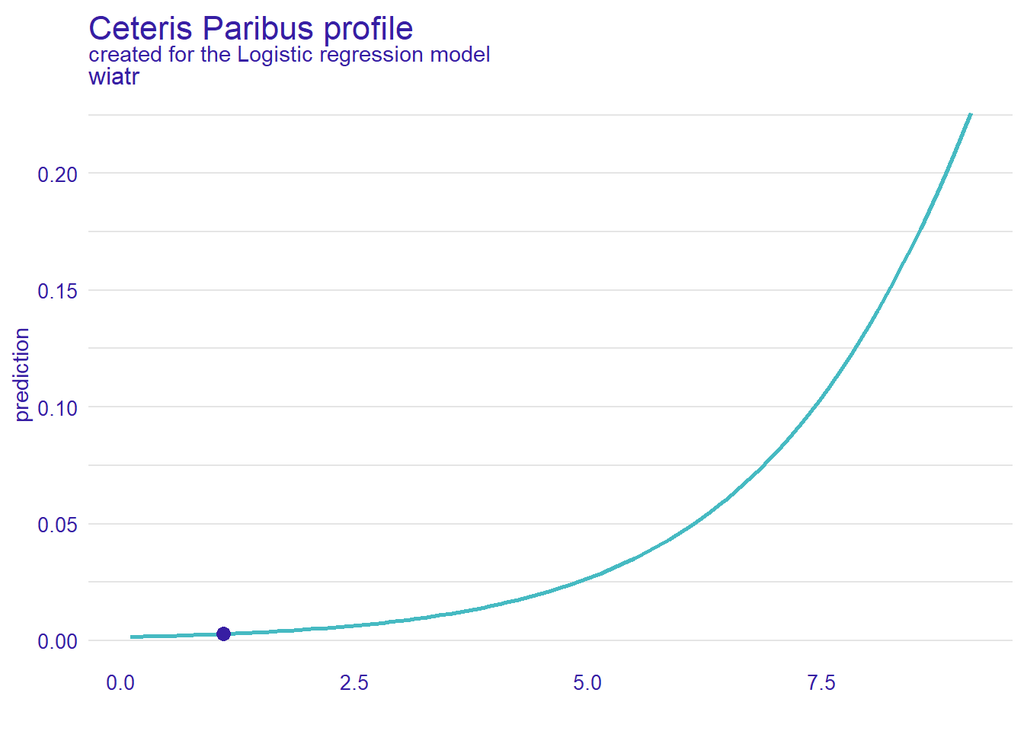

```r
pcp <- predict_profile(explainer = explain_logistic_train_over,
                       new_observation = obs)
plot(pcp, variables = c("wiatr"))
```

Krzywa wskazuje na rosnącą tendencję: im silniejszy wiatr, tym większe przewidywane prawdopodobieństwo zdarzenia, co sugeruje, że “wiatr” ma pozytywny związek z przewidywaniami modelu.

Niebieski punkt na wykresie oznacza przewidywanie modelu dla wartości zmiennej “wiatr” odpowiadającej wybranej obserwacji z zestawu danych. W tym przypadku punkt znajduje się blisko początku osi, co oznacza, że obserwacja ma relatywnie niską wartość zmiennej “wiatr”

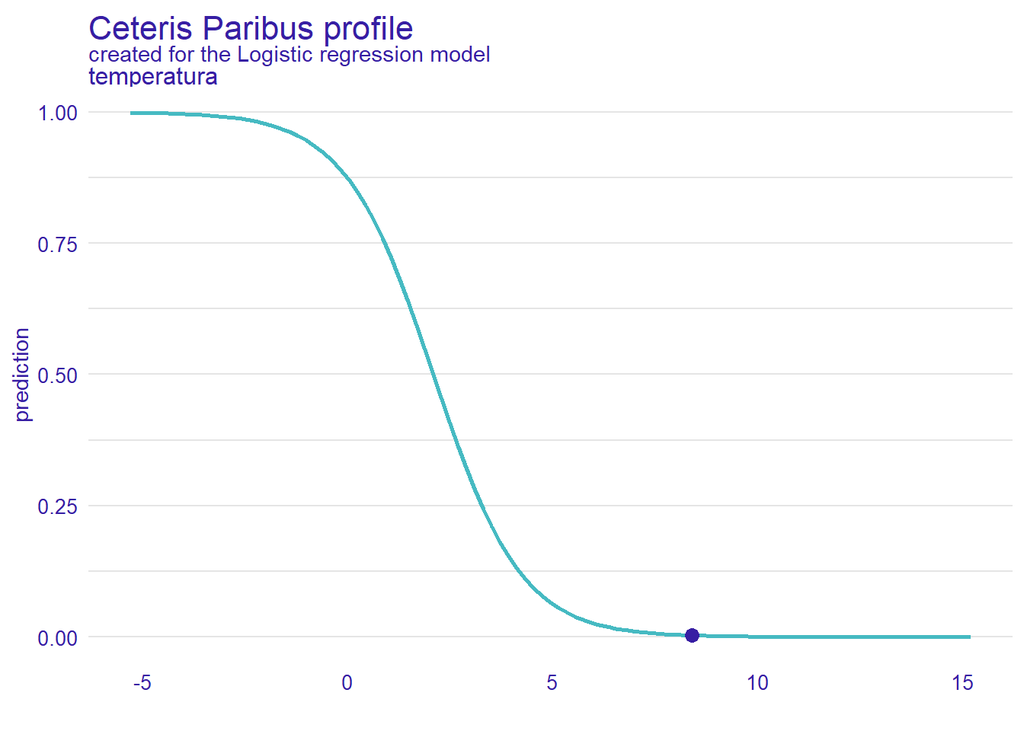

```r
pcp <- predict_profile(explainer = explain_logistic_train_over,
                       new_observation = obs)
plot(pcp, variables = c("temperatura"))
```

Wykres ten ilustruje, jak zmiana temperatury wpływa na przewidywanie modelu regresji logistycznej. Krzywa profilu pokazuje, że z wyższą temperaturą prawdopodobieństwo przewidywanego zdarzenia maleje. Widać wyraźny spadek przewidywanej wartości, kiedy temperatura wzrasta powyżej zera.

```r
plotD3(pcp, variables = c("rosa_01"), variable_type = "categorical", scale_plot=TRUE, label_margin=70)
```

[interactive chart not shown]

```r
plotD3(pcp, variables = c("szron_01"), variable_type = "categorical", scale_plot=TRUE, label_margin=70)
```

[interactive chart not shown]

```r
plotD3(pcp, variables = c("mgla_01"), variable_type = "categorical", scale_plot=TRUE, label_margin=70)
```

[interactive chart not shown]

Model przewiduje brak mgły z większym prawdopodobieństwem zdarzenia, niż wystąpienie mgły. Brak mgły zwiększa szanse na pojawienie się opadów śniegu, co potwierdza także model drzewa decyzyjnego.

```r
plotD3(pcp, variables = c("pokrywa_sniezna_01"), variable_type = "categorical", scale_plot=TRUE, label_margin=70)
```

[interactive chart not shown]

W przypadku wystąpienia pokrywy śnieżnej, występuje znacznie większe prawdopodobieństwo wystąpienia opadów śniegu. Jest to sytuacja zgodna z prawami meteorologii, gdyż opady często są ciągłe w czasie, co powoduje że jeżeli śnieg już spadł, to jest wysokie prawdopodobieństwo kolejnych opadów.

```r
plotD3(pcp, variables = c("deszcz_01"), variable_type = "categorical", scale_plot=TRUE, label_margin=70)
```

[interactive chart not shown]

Wykresy częściowej zależności Wykresy wskazują, że wzorst zachmurzenia oraz wyższa prędkość wiatru wskazują na wyższe prawdopodobieństwo wystąpienia odadów śniegu. Chmury są zazwyczaj miejscem, gdzie zachodzi kondensacja i formowanie kropel wody lub kryształów lodu. Wysokie zachmurzenie może zwiększać ilość dostępnej wilgotności, co sprzyja tworzeniu się opadów śniegu. Oczywistym wskaźnikiem jest także temperatura powietrza, która im jest niższa tym zwiększa prawdopodobieństwo opadów śniegu.

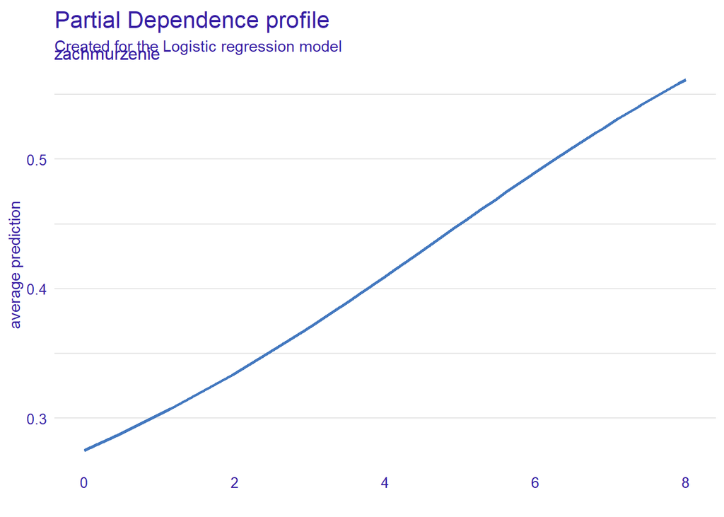

```r
pdp <- model_profile(explainer = explain_logistic_train_over, variables = "zachmurzenie")
plot(pdp)
```

Linia na wykresie wyraźnie rośnie, co sugeruje, że z większym zachmurzeniem model zwiększa prawdopodobieństwo przewidywania śniegu. Innymi słowy, według tego modelu, im większe zachmurzenie, tym większe prawdopodobieństwo, że model przewidzi opady śniegu.

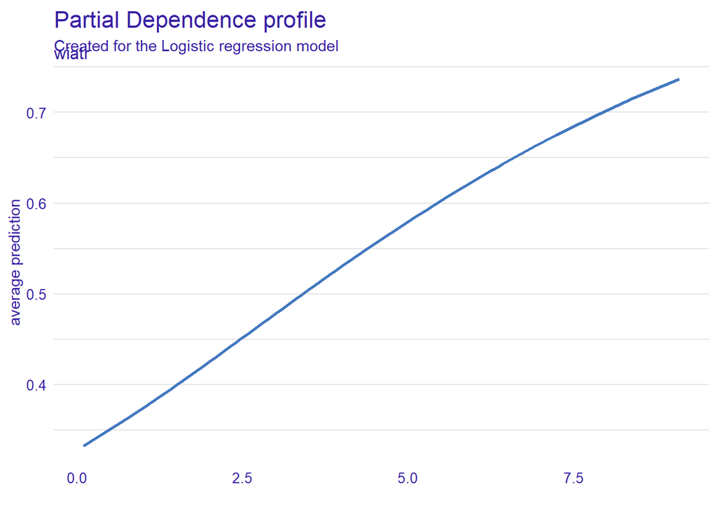

```r
pdp <- model_profile(explainer = explain_logistic_train_over, variables = "wiatr")
plot(pdp)
```

Linia na wykresie stale wzrasta, co wskazuje na to, że w modelu regresji logistycznej wzrost siły wiatru jest skorelowany z wyższym prawdopodobieństwem przewidywanego zdarzenia, które może oznaczać, że silniejszy wiatr zwiększa szanse na przewidzenie opadów śniegu

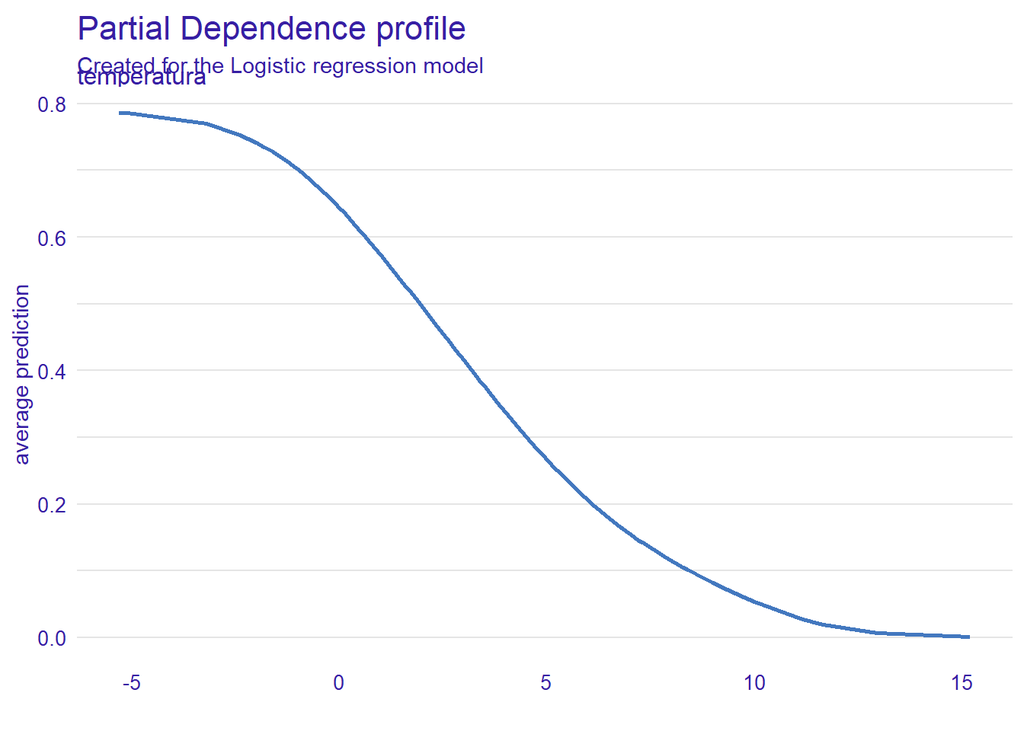

```r
pdp <- model_profile(explainer = explain_logistic_train_over, variables = "temperatura")
plot(pdp)
```

Obserwujemy malejącą linię,oznacza to że niższa temperatura zwiększa szanse na przewidzenie przez model opadów śniegu.

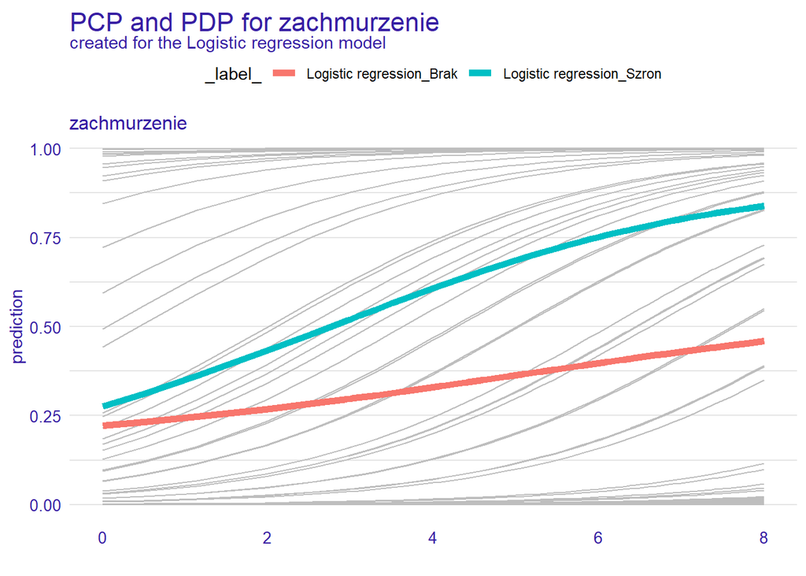

```r
pdp <- model_profile(explainer = explain_logistic_train_over, variables = "zachmurzenie", groups="szron_01")
plot(pdp, geom = "profiles") +
    ggtitle("PCP and PDP for zachmurzenie")
```

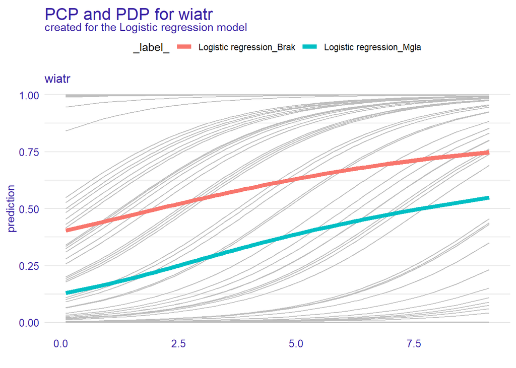

```r
pdp <- model_profile(explainer = explain_logistic_train_over, variables = "wiatr", groups="mgla_01")
plot(pdp, geom = "profiles") +
    ggtitle("PCP and PDP for wiatr")
```

[figure not shown]

```r
pdp <- model_profile(explainer = explain_logistic_train_over, variables = "temperatura", groups="pokrywa_sniezna_01")
plot(pdp, geom = "profiles") +
    ggtitle("PCP and PDP for wiatr")
```

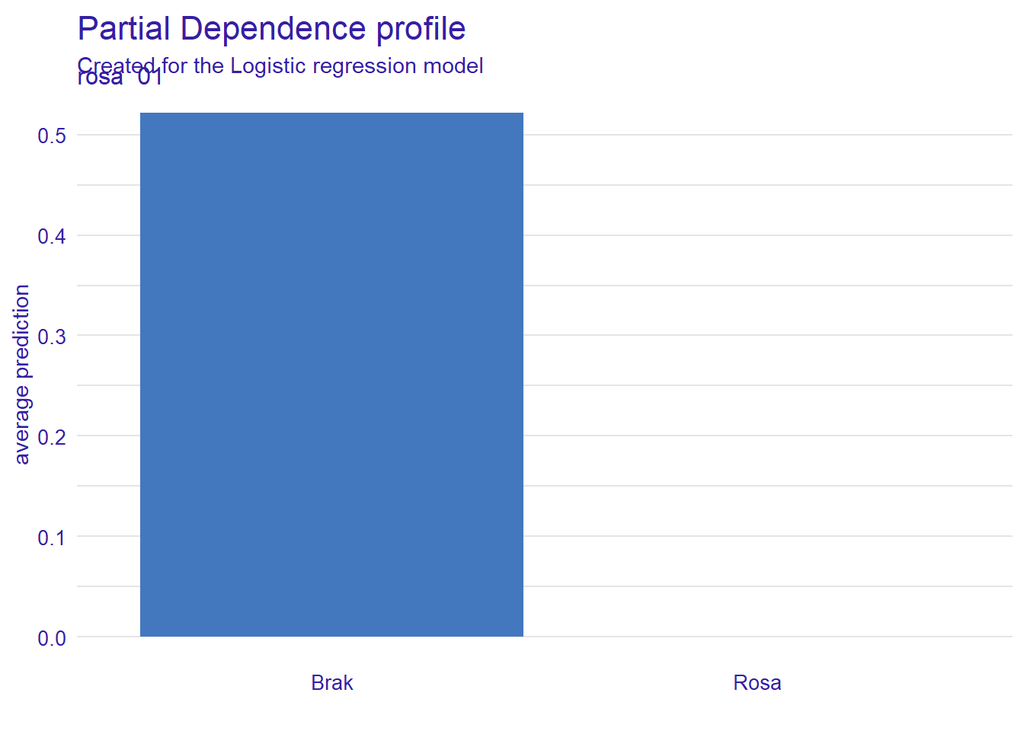

```r
pdp <- model_profile(explainer = explain_logistic_train_over, variables = "rosa_01", variable_type = "categorical")
plot(pdp)
```

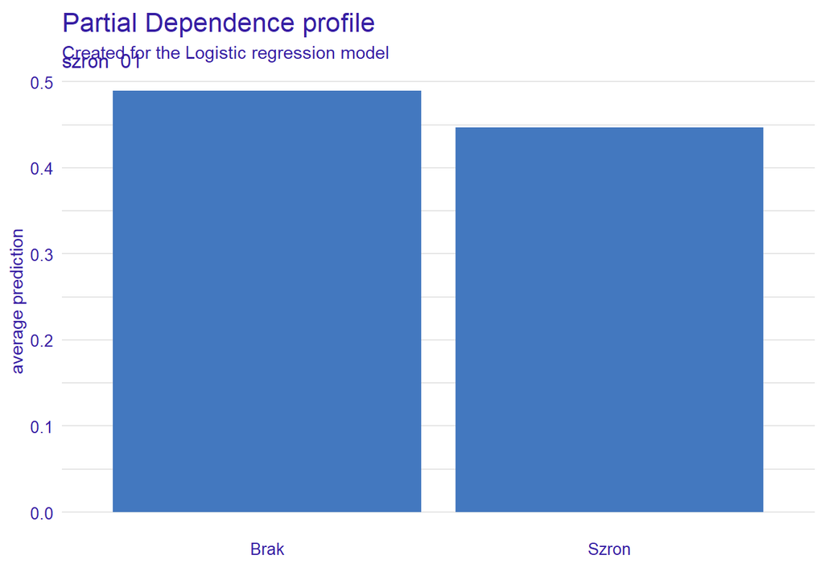

```r
pdp <- model_profile(explainer = explain_logistic_train_over, variables = "szron_01", variable_type = "categorical")
plot(pdp)
```

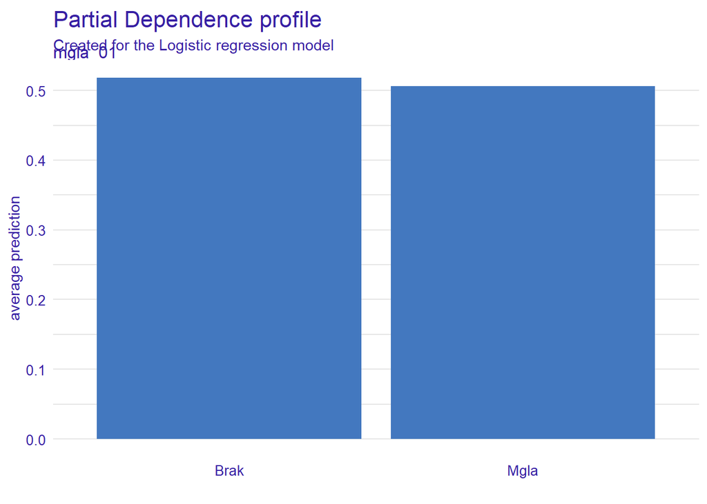

```r
pdp <- model_profile(explainer = explain_logistic_train_over, variables = "mgla_01", variable_type = "categorical")
plot(pdp)
```

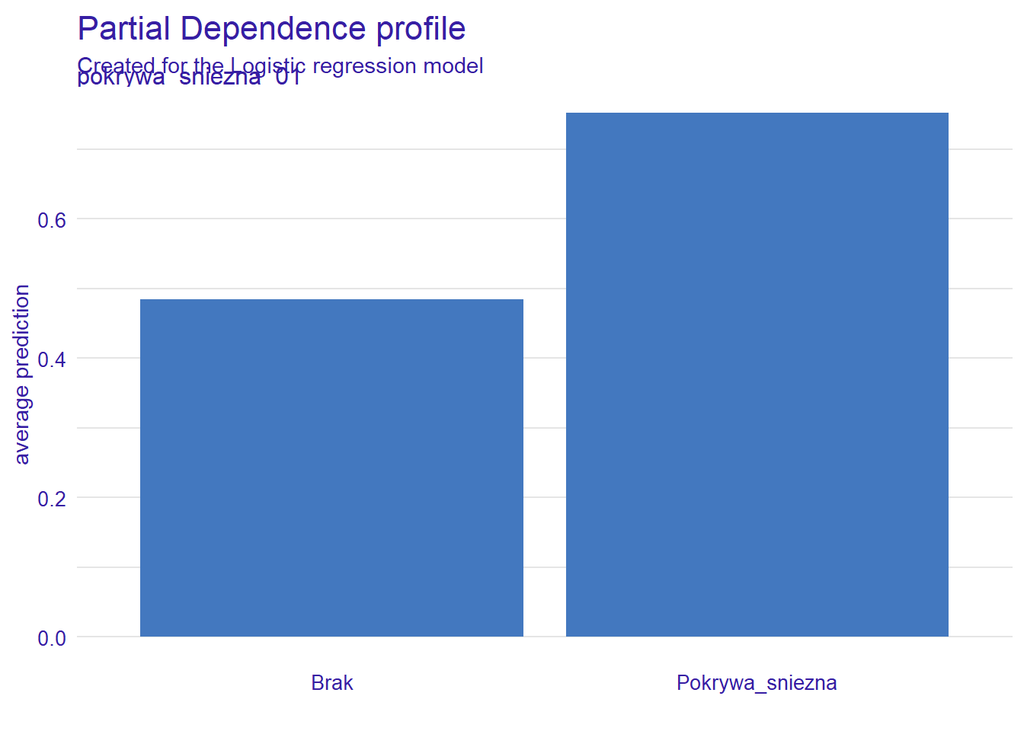

```r
pdp <- model_profile(explainer = explain_logistic_train_over, variables = "pokrywa_sniezna_01", variable_type = "categorical")
plot(pdp)
```

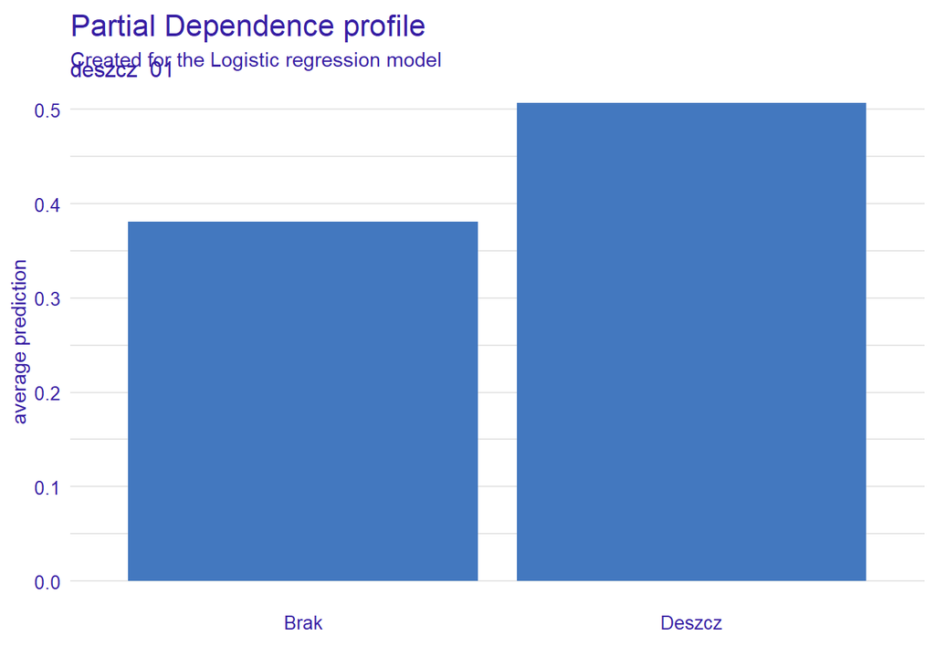

```r
pdp <- model_profile(explainer = explain_logistic_train_over, variables = "deszcz_01", variable_type = "categorical")
plot(pdp)
```